# Report on Atrial Fibrillation dataset analysis

João Miguel Alves

2023-02-14

**Authors**

- João Miguel Alves <sup>1,2</sup> [[0000-0003-1248-4631]](https://orcid.org/0000-0003-1248-4631)
- Daniel Matos <sup>3</sup> [[0000-0002-1554-6116]](https://orcid.org/0000-0002-1554-6116)
- Tiago Martins <sup>1,2</sup> [[0000-0002-2718-7093]](https://orcid.org/0000-0002-2718-7093)
- Pedro Pereira Rodrigues <sup>1,2</sup> [[0000-0001-7867-6682]](https://orcid.org/0000-0001-7867-6682)
- Pedro Adragão <sup>3</sup> [[0000-0003-3729-3137]](https://orcid.org/0000-0003-3729-3137)

**Affiliations**

1. Department of Community Medicine, Information and Health Decision Sciences, Faculty of Medicine, University of Porto, Porto, Portugal
2. CINTESIS – Center for Health Technology and Services Research, Porto, Portugal
3. Cardiology and Eletrophysiology Department, Hospital de Santa Cruz, Centro Hospitalar de Lisboa Ocidental, Carnaxide, Portugal

**Abstract**

**Title:** Predicting atrial fibrillation relapse with explainable artificial intelligence

**Background:** Risk of atrial fibrillation (AF) relapse after pulmonary vein isolation (PVI) procedure can be estimated with the ATLAS score. This score, however, cannot always be calculated as it requires information on all predictive features, being that at least one of them (left atrial volume) is not always available for all patients. Also it does not allow the incorporation of other risk factors as medical knowledge is updated, nor does it improve as new patients’ data is gathered. We aimed to develop an artificial intelligence predictive model which can calculate the risk of AF relapse after PVI procedure from available patient data, hence improving as new evidence is accumulated. Additionally, this model can effectively predict the outcome even in the absence of any of its predictive features. Furthermore, our model can incorporate new medical knowledge at any time, as *eg.* new known or suspected risk factors for the outcome variable.

**Methods:** The model was developed based on a Bayesian network (BN) for calculation of conditional probabilities of risk based on each patient’s clinical condition. The network structure was built based on expert knowledge, as well as inference from data trough hill‑climbing algorithm. Conditional probabilities were estimated through a Bayesian posterior estimator. The models were tested for 5, 6 and 7 predictors of AF relapse, and validated by four different sampling techniques.

**Results:** Apart from the previously known feature relations, the learnt network structure revealed an existing relation between body mass index and epicardial fat, consistent with the current medical literature. This relation was explored as alternative predictor in the absence of evidence about epicardial fat. We evaluated models’ performance in predicting AF relapse using as predictors age, sex, smoking, persistent AF, and obstructive sleep apnea (5 predictors), to which were added body mass index (6) or left atrium volume and epicardial fat (7 predictors). Predictive performances were measured by AUC-ROC at 0.661 (CI 0.603-0.718), 0.703 (CI 0.652-0.753) and 0.752 (CI 0.701-0.800) respectively.

**Conclusion:** The models show an acceptable diagnostic accuracy even in the absence of some of predictive features. It thus provides a valid clinical tool for estimating risk of AF relapse with easily obtainable clinical variables. Naturally, the models are increasingly more accurate as more predictive features are included, for which all predictors should be used whenever available.

# 1 Introduction

The ATLAS score [[1]](https://pubmed.ncbi.nlm.nih.gov/29016770/) provides a risk estimate to predict the rate of Atrial Fibrillation (AF) recurrence after pulmonary vein isolation (PVI) procedure. However, it suffers from the typical limitations of clinical scores, such as the use of a small number of independent variables for the prediction of a single dependent variable, which remains unchanged throughout the patient’s clinical course.

The ATLAS score is based on 5 independent variables, being: Age, Sex, Smoking habits, Left atrial volume (LAV), and occurrence of paroxysmal AF. It is strongly dependent on the measurement of the LAV as its main driver, which is not always possible to obtain. Similarly to other clinical scores, it is unfeasible to be calculated in the absence of any of its predicting variables.

An additional limitation is that it establishes an upfront risk profile, which cannot be revised or readjusted during the patient’s subsequent follow-up. Also, other potential risk factors (as *eg.* Epicardial fat or Obstructive Sleep Apnea) are not taken into consideration for the calculation of this score.

This analysis proposes the structuring and fitting of a Bayesian Network (BN) that can represent medical knowledge on this field. This model can then be used to predict the occurrence of Atrial Fibrillation in patients, as an enhanced alternative to the ATLAS score.

# 2 Methods

## 2.1 Dataset

We analysed the clinical data of 480 patients being followed for atrial fibrillation (AF) treatment at a Portuguese hospital. All patients have been admitted with either paroxysmal or persistent AF, and all were treated with radiofrequency pulmonary vein isolation (PVI) procedure. After surgical procedure, patients were followed-up for up to 3 years to monitor possible post-surgical relapses for atrial fibrillation. Data characterization is exhibited in Table 1 below.

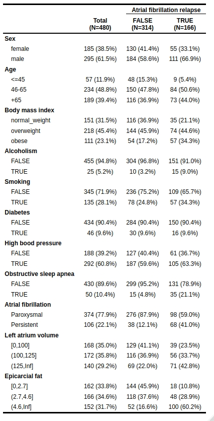

**Table 1:** Data characterization

All numeric features in the data set – Age, BMI, LeftAtrium_Vol and EpiFat – were discretized into classes. Table 2 below describes all features and their classes.

| Feature | Meaning | Classes |
| --- | --- | --- |
| Sex | patient’s sex | female, male |
| Age | patient’s age | <=45, 46-65, +65 |
| BMI | body mass index | normal_weight, overweight, obese |
| HBP | high blood pressure | true, false |
| OSA | obstructive sleep apnea | true, false |
| Diabetes | diabetes | true, false |
| Alcohol | active alcoholism | true, false |
| Smoking_active | active smoking | true, false |
| Persistent_AF | type of atrial fibrillation (AF) | paroxysmal, persistent |
| LeftAtrium_Vol | left atrium volume | [0,100], (100,125], (125,Inf] |
| EpiFat | epicardial fat | [0,2.7], (2.7,4.6], (4.6,Inf] |
| AF_relapse | atrial fibrillation relapse | true, false |

**Table 2:** Features dictionary and classes per feature

## 2.2 Model training

We aimed to build a Bayesian Network (BN) model, with the network’s structure being built based on expert knowledge as well as inference from data.

**Network structure:** The network was intentionally built to represent, as closely as possible, the medical knowledge in this field. We included (whitelisted) known clinical relations between features, such as *i)* known risk factors for diseases expressed in the data set, as diabetes, high blood pressure (HBP), and obstructive sleep apnea (OSA); and *ii)* known AF relapse predictive features, as the ATLAS score features (age, sex, smoking, persistent AF and left atrium volume), as well as epicardial fat [[2]](https://academic.oup.com/europace/article/24/8/1201/6546753) [[3]](https://onlinelibrary.wiley.com/doi/10.1111/pace.13825) [[4]](https://academic.oup.com/eurheartj/article/38/17/1294/3056898) [[5]](https://onlinelibrary.wiley.com/doi/abs/10.1111/obr.13277) and obstructive sleep apnea (OSA) [[6]](https://www.ahajournals.org/doi/full/10.1161/JAHA.121.022560) [[7]](https://pubmed.ncbi.nlm.nih.gov/33516410/) [[8]](https://jamanetwork.com/journals/jamacardiology/article-abstract/2674722), as suggested by recent medical literature.

Other potential relations were left for the artificial intelligence algorithm to discover. For this step we applied a hill-climbing algorithm, a score-based structure learning method which optimizes the Bayesian Information Criterion (BIC) for the network structure.

**Model fitting:** After the network structure was defined, a model could be set to learnt the conditional probabilities among all related features, based on the observations from a training data set. With the model fitted in this fashion, it was now possible to query the model to compute the estimated probability of a given patient having AF relapse given her clinical characteristics – *eg.* the model can be asked *“based on the available data, what is the probability of a patient having a AF relapse knowing that is female, +65 years-old, and non-smoker”*.

## 2.3 Model validation

Model validation was carried by repeated sampling, training and testing cycles. At each cycle, we took a random sample of the original data set to be used as training data. This sample was then used to train a conditional probabilities model as previously described. The observations not included in the training set were then used as test set. For testing, we queried the model to compute the conditional probability of having AF relapse for each patient in the test set. The results were stored for each tested observation. The process was then repeated a number of times until each observation had been used for testing at least 30 times. Finally, the calculated probability of AF relapse for each patient was assumed as the average of all probabilities calculated at each cycle for that patient.

The random samples for training the model were obtained through four different sampling processes: *i)* bootstrapping, which in average uses 63.2% of the observations for training, and *ii)* fixed splitting in train and test set, with ratios of 80:20 *iii)* 90:10, and *iv)* 95:5 – ie. with 80%, 90% and 95% of the observations respectively being used for training the model. With these processes, we aimed to achieve a good estimator for the generalization error. We compared the average predicted probability with each sampling method with the true observation of AF relapse for each patient, and measured the performance through the area under the receiver operating characteristic curve (AUC-ROC).

This analysis was carried using R version 4.2.2, with packages *bnlearn* and *pROC*.

# 3 Results

## 3.1 Bayesian network structure

The network structure defined by expert knowledge and inference from data is represented in the Figure 1 below.

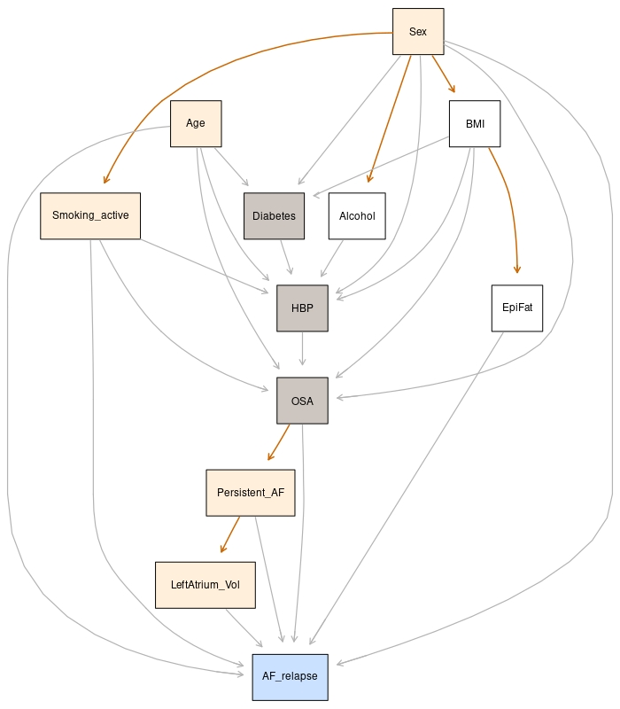

**Fig.1:** Bayesian network structure. Orange colored arcs represent relations discovered by the artificial intelligence algorithm, suggesting meaningful relations between features.

Colors in nodes represent:

- `[grey]` : diseases with attributed (whitelisted) risk factors: `Diabetes`, `HBP`, `OSA`
- `[sand]` : ATLAS’ 5 predictive variables: `Age`, `Sex`, `Smoking_active`, `LeftAtrium_Vol`, `Persistent_AF`
- `[blue]` : outcome variable: `AF_Relapse`

Colors in arcs represent:

- `[light grey]` : whitelisted relations, *ie.* known risk factors
- `[orange]` : relations discovered by the hill‑climbing algorithm

As noted in this representation, the model suggests relations not initially declared, such as: `BMI`→`EpiFat`, `OSA`→`Persistent_AF`, and `Persistent_AF`→`LeftAtrium_vol`. Also `Sex` appears to be related with active smoking, alcoholism and body mass index. All these relation are not surprising and are even supported by current medical literature, hence providing a reasonable representation of clinical knowledge in this field.

Regarding the outcome variable `AF_relapse`, the model did not find any other relevant relations apart from those previously whitelisted.

An alternative representation of this network is exhibited in the Figure 2 below, exhibiting relative frequencies per class at each node.

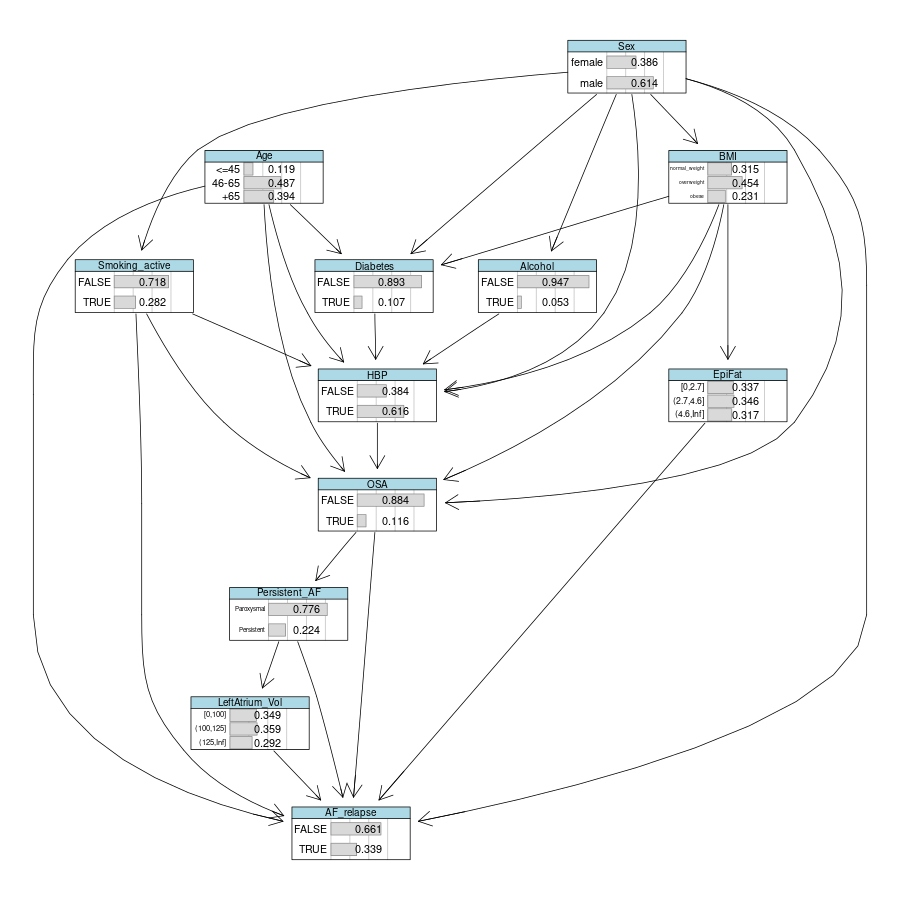

**Fig.2:** Bayesian network structure with relative frequencies per class at each node.

## 3.2 Relapse probabilities calculation

With each trained model, we calculated the conditional probability of `AF relapse` for each patient at the test set, considering their current clinical conditions. For these calculations, we used in turns 7, 5 or 6 predictive features, as explained in the sections to follow.

### 3.2.1 7 predictors

In a first stage, the calculation considered the clinical state for all 7 `AF_relapse` parent nodes represented in the network structure: `Age`, `Sex`, `Smoking_active`, `Persistent_AF`, `LeftAtrium_Vol`, `EpiFat` and `OSA`.

Model’s performance for classifying AF relapse with all parent nodes (7 predictors) was computed to an average AUC value of 0.752 (CI 0.701-0.800) for all sampling methods.

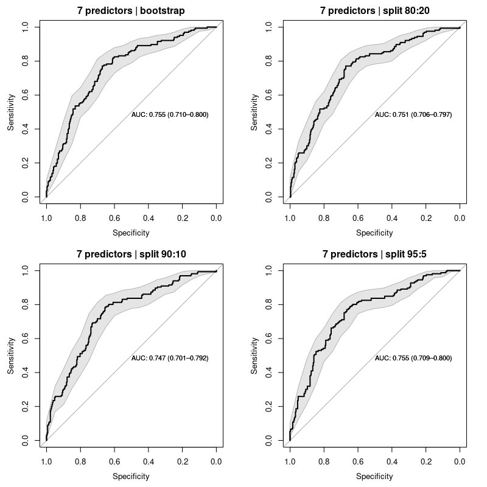

**Fig.3:** ROC curves for 7 predictors: Age, Sex, Smoking, Persistent AF, Left atrium volume, Epicardial fat and OSA. AUC values averaged 0.752 (CI 0.701-0.800).

### 3.2.2 5 predictors

From the 7 predictive features used in the previous calculation, 2 are usually difficult to obtain: `LeftAtrial_Vol` and `EpiFat`. These 2 features are usually calculated by diagnostic imaging, which is not always performed for all patients. In some cases, the physician does not have access to those measurements, which impairs the calculation of medical scores that require any of those values, (*eg.* the ATLAS score).

The purpose of this test was to evaluate models performance without those 2 features, hence simulating a frequent real‑life scenario. AS such, we calculated the conditional probability of `AF relapse` for each patient at the test set, considering only 5 of its parent nodes: `Age`, `Sex`, `Smoking_active`, `Persistent_AF`, and `OSA`. The remaining 2 parent nodes `LeftAtrium_Vol` and `EpiFat` were disregarded from evidence for the calculation of the conditional probabilities.

Model’s performance for classifying AF relapse with these 5 predictors was as expectably lower, with a computed AUC average of 0.661 (CI 0.603-0.718) for all sampling methods.

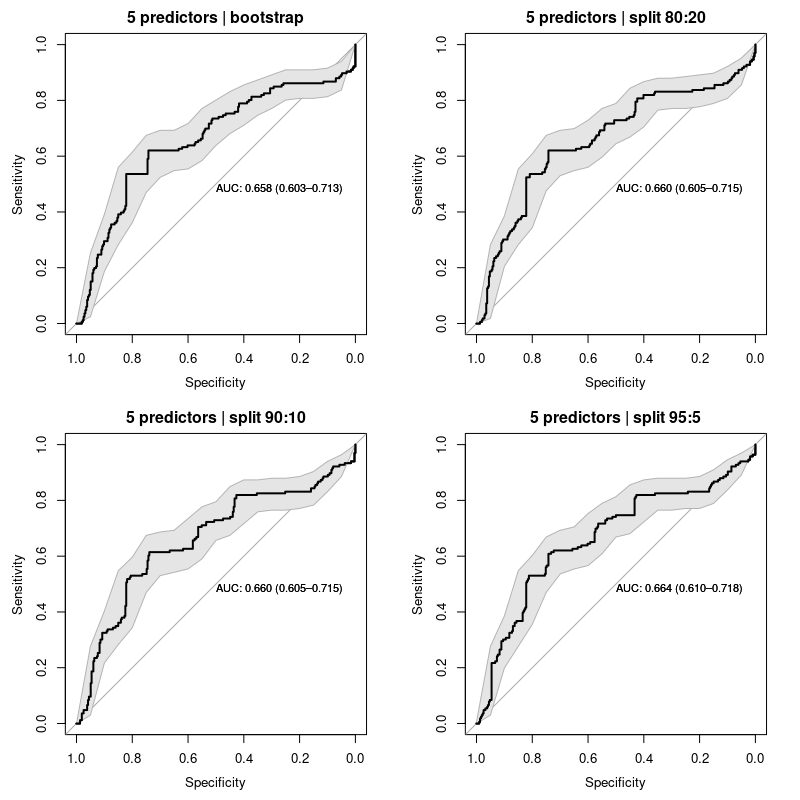

**Fig.4:** ROC curves for 5 predictors: Age, Sex, Smoking, Persistent AF, and OSA. AUC values averaged 0.661 (CI 0.603-0.718).

### 3.2.3 6 predictors

The predictive performance with only the previous 5 predictors seems to be somehow unexceptionable. However, it can be noted from the defined Bayesian network structure (Fig. 1) that the node `EpiFat` has as single parent `BMI`, meaning that the latter directly influences the former. As such, the absence of information on `EpiFat` for a given patient can be partially compensated by its information on `BMI` value. This poses an interesting possibility, especially when observed that body mass index is usually an available or easy to obtain feature for any patient.

The rational for this test was then to gauge the predictive power of a model when using the 5 predictors in the previous experience, plus information on `BMI` node. All these 6 features – `Age`, `Sex`, `Smoking_active`, `Persistent_AF`, `OSA`, and `BMI` – are usually easily available clinical variables for physicians’ evaluation, which do not require the use of additional complex or expensive diagnosis means. Therefore, this setting simulates models’ predictive power on a likely real‑life scenario.

For this test, we calculated the conditional probability of `AF relapse` for each patient at the test set, considering evidence on `Age`, `Sex`, `Smoking_active`, `Persistent_AF`, `OSA` and `BMI`. The absence of information on `EpiFat` node is hence compensated by evidence on `BMI` for the calculation of the conditional probabilities. For the purpose of this test, any information on `LeftAtrium_Vol` and `EpiFat` were disregard.

Model’s performance for classifying AF relapse with these 6 predictors resulted in a computed AUC average of 0.703 (CI 0.652-0.753) for all sampling methods.

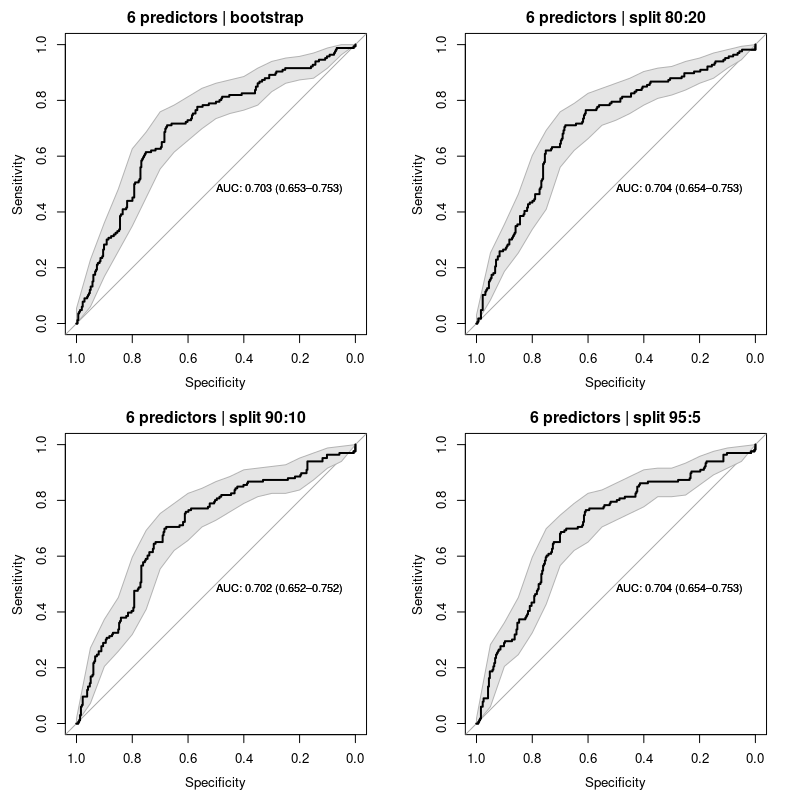

**Fig.5:** ROC curves for 6 predictors: Age, Sex, Smoking, Persistent AF, OSA and BMI. AUC values averaged 0.703 (CI 0.652-0.753)

# 4 Discussion

The model based on a Bayesian Network, built from both expert knowledge and data inference, shows a good discriminatory power for predicting the relapse of Atrial Fibrillation (AF) in patients after surgical ablation, particularly when using the tested 6 or 7 predictors setting. When using evidence from all the parent nodes of our outcome variable, the model performs with computed AUC value of roughly 0.75, interpreted as an acceptable diagnostic accuracy [[9]](https://www.sciencedirect.com/science/article/pii/S1556086415306043).

In the absence of information on `LeftAtrial_Vol` and `EpiFat` as predictive features, models have an expectably lower performance with computed AUC values near 0.66. This finding suggests that these two features have a high weight on the model performance — which is consistent with the finding on ATLAS score [[1]](https://pubmed.ncbi.nlm.nih.gov/29016770/) that left atrial volume has the highest weight on that score’s predictive power.

Nonetheless, this experience also shows that the absence of information on `EpiFat` can be partially compensated by evidence from `BMI`, as this is its parent node. Considering clinical practice, this poses an interesting possibility, as values for body mass index are usually available for clinical evaluation for most patients. Improvement in models performance is placed again within the acceptable range, with computed AUC values around 0.70.

This data-based approach for predicting atrial fibrillation relapse can be regarded as an enhancement of the ATLAS score, as it is based on its 5 predicting features, to which 2 other additional features were added. The Bayesian Network model has as advantages i) the possibility of being calculated even in cases of incomplete information (*eg.* when there is no information about the left atrial volume), 2) the possibility of incorporating new medical knowledge on potential risk factors at any time (*eg.* including epicardial fat, OSA or others as predictive features) by rebuilding the bayesian network structure accordingly, and 3) the possibility of being continuously retrained with new data as new patient information is added to the model, hence progressively providing more accurate results as new evidence is included in the calculation.

# 5 References

[1] Mesquita J, Ferreira AM, Cavaco D, et al. *Development and validation of a risk score for predicting atrial fibrillation recurrence after a first catheter ablation procedure - ATLAS score*. Europace. 2018;20(FI_3):f428-f435. doi:10.1093/europace/eux265

[2] Poggi AL, Gaborit B, Schindler TH, Liberale L, Montecucco F, Carbone F. *Epicardial fat and atrial fibrillation: the perils of atrial failure*. Europace. 2022;24(8):1201-1212. doi:10.1093/europace/euac015

[3] Zhou M, Wang H, Chen J, Zhao L. *Epicardial adipose tissue and atrial fibrillation: Possible mechanisms, potential therapies, and future directions*. Pacing Clin Electrophysiol. 2020;43(1):133-145. doi:10.1111/pace.13825

[4] Wong CX, Ganesan AN, Selvanayagam JB. *Epicardial fat and atrial fibrillation: current evidence, potential mechanisms, clinical implications, and future directions*. Eur Heart J. 2017;38(17):1294-1302. doi:10.1093/eurheartj/ehw045

[5] Couselo-Seijas M, Rodríguez-Mañero M, González-Juanatey JR, Eiras S. *Updates on epicardial adipose tissue mechanisms on atrial fibrillation*. Obes Rev. 2021;22(9):e13277. doi:10.1111/obr.13277

[6] Chen W, Cai X, Yan H, Pan Y. *Causal Effect of Obstructive Sleep Apnea on Atrial Fibrillation: A Mendelian Randomization Study*. J Am Heart Assoc. 2021;10(23):e022560. doi:10.1161/JAHA.121.022560

[7] Linz D, Nattel S, Kalman JM, Sanders P. *Sleep Apnea and Atrial Fibrillation*. Card Electrophysiol Clin. 2021;13(1):87-94. doi:10.1016/j.ccep.2020.10.003

[8] Linz D, McEvoy RD, Cowie MR, et al. *Associations of Obstructive Sleep Apnea With Atrial Fibrillation and Continuous Positive Airway Pressure Treatment: A Review*. JAMA Cardiol. 2018;3(6):532-540. doi:10.1001/jamacardio.2018.0095

[9] Mandrekar JN. *Receiver operating characteristic curve in diagnostic test assessment*. J Thorac Oncol. 2010;5(9):1315-1316. doi:10.1097/JTO.0b013e3181ec173d